# Are we more civilized today?

Mathilde Petersen

2026-03-19 14:51:19.958121

```r
knitr::opts_chunk$set(echo = TRUE,
                      message=FALSE)
```

# Explore Homicide rates in NW Europe

In this exercise, you will load a Manuel Eisner’s dataset that captures the developments in homicides from Middle Ages to 20th century.

**Your task: Explore the data and create visualisations as instructed in the script.**

- **Upload to Github this .Rmd file with solutions and its .html knitted version.**
- **Submit to Brightspace a document that follows the template and contains (1) URL of this script and its knitted version in Github, (2) one plot of your choice, and (3) answer of 250 words to the Final Question.**

This exercise is based on the dataset provided by [OurWorldInData project](https://ourworldindata.org/homicides) based at the Oxford University.

## The long-term trend in Homicides in Western Europe

Understanding how homicide rates have changed prior to the modern era requires the help of historians and archivists. Manuel Eisner, a criminology professor at the University of Cambridge, and his colleagues published the Historical Violence Database a compilation of data on long-term trends in homicide rates, in addition to qualitative information such as the cause of death, perpetrator and victim. This database is limited to countries with relatively complete historical records on violence and crime – mainly Western Europe and the US.

Starting in the second half of the nineteenth century, these European regions have consistent police records of those accused of murder or manslaughter and annual counts of homicide victims. To go back further in time, reaching as far back as the thirteenth century, Eisner collected estimates (from historical records of coroner reports, court trials, and the police) of homicide rates made in over ninety publications by scholars.

Homicide rates – measured as the number of homicides per 100,000 individuals – up to 1990 are sourced from Eisner’s (2003) publication and the Historical Violence Database.

Are homicide rates in Europe today lower or higher than in the past? Using the provided dataset, display and describe the long-run homicide rates for the five European regions: Italy, England, Germany, Netherlands and Scandinavia.

```r
library(tidyverse)
```

## Load the available data from ourworldindata.org

You should always interrogate the source of your data. Who compiled it, from where, what is missing, how representative the data are? Check the data/Metadata.txt to learn about the data provenance.

```r
Western_Europe <- read_csv("data/homicide-rates-across-western-europe.csv")
```

## Inspect the data

How clean and analysis-ready is the dataset? Do you understand what the column names represent? What is the difference between rate and homicide number?

```r
head(Western_Europe)
```

```
## # A tibble: 6 × 4
##   Entity  Code   Year Homicide rate in Europe over long-term (per 100,000) (ho…¹
##   <chr>   <chr> <dbl>                                                      <dbl>
## 1 England <NA>   1300                                                         23
## 2 England <NA>   1550                                                          7
## 3 England <NA>   1625                                                          6
## 4 England <NA>   1675                                                          4
## 5 England <NA>   1725                                                          2
## 6 England <NA>   1775                                                          1
## # ℹ abbreviated name:
## #   ¹`Homicide rate in Europe over long-term (per 100,000) (homicides per 100,000 people)`
```

```r
glimpse(Western_Europe)
```

```
## Rows: 206
## Columns: 4
## $ Entity                                                                                <chr> …
## $ Code                                                                                  <chr> …
## $ Year                                                                                  <dbl> …
## $ `Homicide rate in Europe over long-term (per 100,000) (homicides per 100,000 people)` <dbl> …
```

Ok, the data look good except for the column `Homicide rate in Europe over long-term (per 100,000)` which is not very easy to work with.

- Use the `names()` function and assignment key to relabel this column to `homicides_per_100k`

```r
# names() function produces the names of columns as a character vector with 4 elements
names(Western_Europe)
```

```
## [1] "Entity"
## [2] "Code"
## [3] "Year"
## [4] "Homicide rate in Europe over long-term (per 100,000) (homicides per 100,000 people)"
```

```r
# If we can select the fourth element, we can also rename it / reassign a name to it
names(Western_Europe)[4] <- "homicides_per_100k"
names(Western_Europe)[4]
```

```
## [1] "homicides_per_100k"
```

```r
# check the new name!
names(Western_Europe)
```

```
## [1] "Entity"             "Code"               "Year"
## [4] "homicides_per_100k"
```

```r
head(Western_Europe)
```

```
## # A tibble: 6 × 4
##   Entity  Code   Year homicides_per_100k
##   <chr>   <chr> <dbl>              <dbl>
## 1 England <NA>   1300                 23
## 2 England <NA>   1550                  7
## 3 England <NA>   1625                  6
## 4 England <NA>   1675                  4
## 5 England <NA>   1725                  2
## 6 England <NA>   1775                  1
```

Now, that you have looked at what the data looks like and what it represents, and streamlined it, let’s see what big picture it contains.

## Let’s see what the long-term trend is in homicides

- use `ggplot()` function and remember the`+` at the end of the line
- chose a meaningful `geom_......()` for geometry (hint: points are not great)
- load `Year` on the `x` axis and `homicides_per_100k` column in y axis
- to color individual country entries consistently, assign the country column to the argument `color`.
- provide meaningful title and axis labels
- remember to change the `eval` flag so that the code chunk renders when knitted

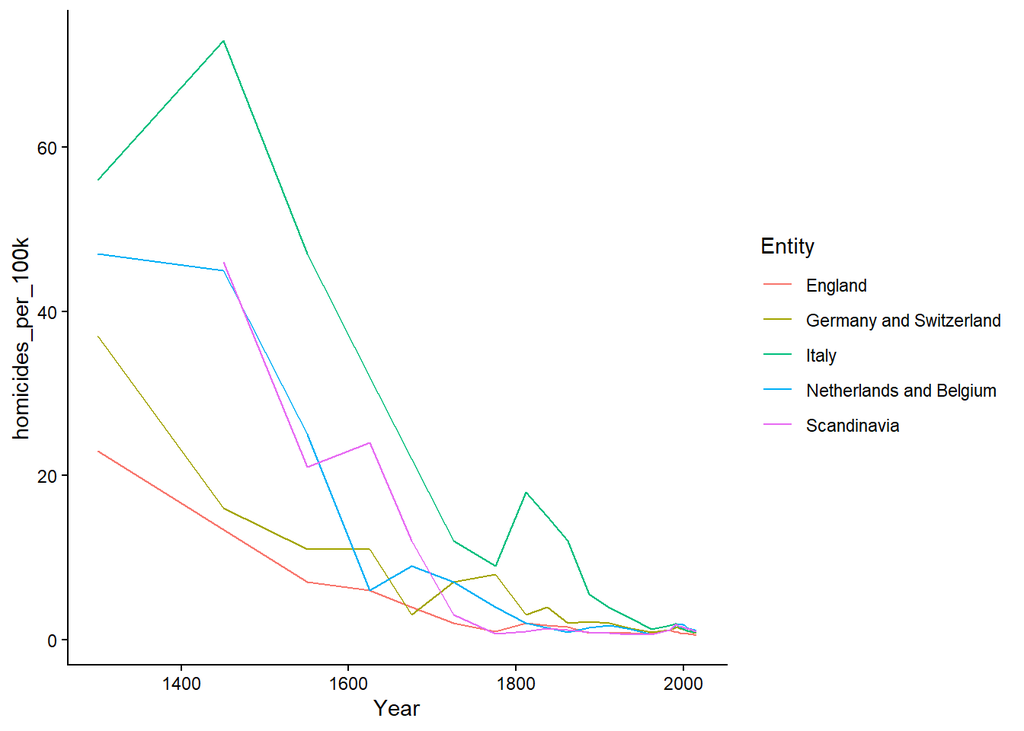

```r
Western_Europe %>%
  ggplot(aes(x=Year,y=homicides_per_100k,color=Entity))+
  geom_line()+
  theme_classic()
```

Alright, the homicide rates should all be descending over time. What a comfort. But the viz is not super clear. Let’s check the rates for individual countries.

## Uncouple the homicides of individual countries for easier view

You can visualize each country’s trend separately by adding an extra argument to the ggplot, the `facet_wrap()` and feeding it the country column. If in doubt, check your ggplot tutorial and your country column name for exact usage.

- reuse the ggplot from the chunk above
- insert `facet_wrap()` after the specification of geometry to split countries in separate charts
- change the facet “layout” to two columns and three rows so that the trends are easier to see in horizontal layout.

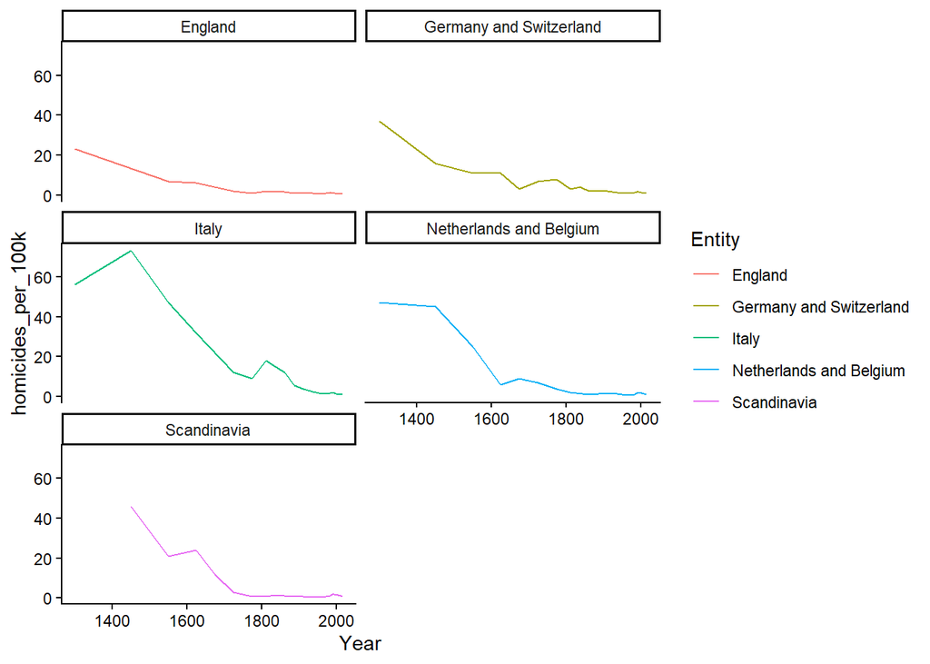

```r
Western_Europe %>%
  ggplot(aes(x=Year,y=homicides_per_100k,color=Entity))+
  geom_line()+
  facet_wrap(~Entity,ncol=2)+
  theme_classic()
```

## Compare the trends in homicide with the pattern of reign duration among Danish rulers through time.

- Load your Danish king dataset. Hopefully it is tidy and your years and duration of reign are all numeric.
- You need to have a consistent way of plotting the rulers’ reign on the x axis, so I recommend you create a midyear column by calculating the middle of each monarch’s rule (Hint: `midyear` = `endyear` - (`endyear`-`startyear`)/2)
- Start a ggplot plotting midyear on x axis and duration on y axis
- Try `geom_smooth()` for geometry
- Provide meaningful labels and a title
- How would you characterize the trend compared to the homicides above? The two graphs show opposite long-term trends. The duration of Danish monarchs’ reigns appears to increase over time, indicating that monarchs tend to rule for longer periods in more recent history. In contrast, homicide rates across European regions show a clear decline over time. This suggests a negative relationship between the two patterns: as societies develop over time, violence (measured by homicide rates) decreases, while political stability (reflected in longer reigns) increases.

```r
# MY CODE:
library(tidyverse)
kings <- read.csv("data/kings.csv",na=c("NULL",""))
head(kings)
```

```
##                Name House Start_year End_year Birth_year Death_year Gender
## 1    Gorm den Gamle  Gorm        936      958        908        958      M
## 2 Harald 1. Blåtand  Gorm         NA       NA        936        985     M
## 3      Toke_Gormsen  Gorm        985      986         NA        986     M
## 4  Svend 1. Tveskæg  Gorm         NA       NA         NA       1014     M
## 5         Harald 2.  Gorm       1014     1018        963         NA     M
## 6 Knud 1. den Store  Gorm       1018     1035         NA       1035     M
##            Dynasty                                            Source  BirthDMY
## 1 Jellingdynastiet      https://da.wikipedia.org/wiki/Gorm_den_Gamle       908
## 2 Jellingdynastiet https://da.wikipedia.org/wiki/Harald_Bl%C3%A5tand       936
## 3 Jellingdynastiet        https://da.wikipedia.org/wiki/Toke_Gormsen      <NA>
## 4 Jellingdynastiet  https://da.wikipedia.org/wiki/Svend_Tvesk%C3%A6g 17/04/963
## 5 Jellingdynastiet           https://da.wikipedia.org/wiki/Harald_2.       994
## 6 Jellingdynastiet      https://da.wikipedia.org/wiki/Knud_den_Store       995
##     DeathDMY
## 1        958
## 2        987
## 3       <NA>
## 4 03/02/1014
## 5       1018
## 6 12/11/1035
```

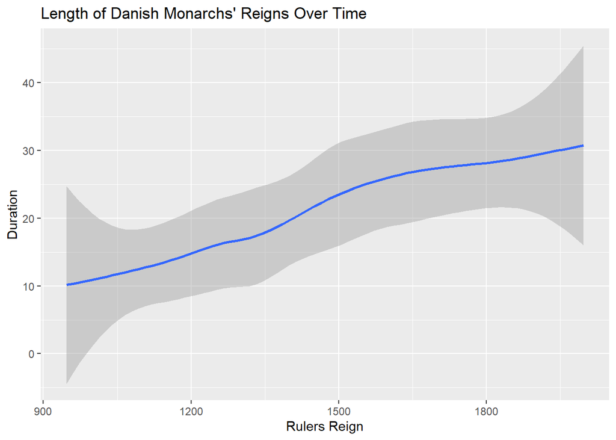

```r
kings %>%
  mutate(Duration = End_year - Start_year) %>%
  mutate(Midyear = End_year - Duration/2) %>%
  ggplot(aes(x=Midyear, y=Duration))+
  geom_smooth()+
  ggtitle("Length of Danish Monarchs' Reigns Over Time")+
  labs(x="Rulers Reign",
  y ="Duration")
```

1. Plot: In the facetted plot above, move the legend from the current position on the side to below the facets, and label it “Country” instead of “Entity”.

Western_Europe %>% ggplot(aes(x=Year,y=homicides_per_100k,color=Entity))+ geom_line()+ facet_wrap(~Entity,ncol=2)+ theme_classic()+ theme(legend.position = “bottom”) + labs(color = “Country”)

2. Rmarkdown:
- edit the author of the document, and convert ‘Final Tasks’ into heading #2 (like the other headings)
- add a `floating table of contents` to your Rmarkdown document,
- provide informative `chunk-names` and edit flags in your R chunks to `TRUE`, and
- automatically generate a `timestamp` to show when the document was last updated. (Hint: check the Rmarkdown episode in our Data Carpentry tutorial)

### Final question:

*In <250 words articulate your answer on the basis of the data visualisations to the following question*: **are we more civilized today?** Based on the visualizations, there is evidence to suggest that we have become more “civilized” over time, at least when measured by violence and stability. The homicide data show a clear and substantial decline across all regions from the Middle Ages to the present, indicating that violence has decreased significantly. This supports the idea that societies have developed stronger norms, institutions, and forms of social control that reduce violent behavior. At the same time, the graph of Danish monarchs’ reigns shows a general increase in the length of rule over time. Longer reigns can be interpreted as a sign of greater political stability, fewer conflicts over succession, and more consolidated state structures. Together these trends point in the same direction: declining violence and increasing stability. This suggests that modern societies are more orderly and predictable than in the past, which can be seen as a form of increased “civilization.” However, these measures capture only certain aspects of civilization - mainly violence and political stability and do not account for other dimensions such as inequality, war, or structural violence. Therefore, while the data support the idea that we are more civilized in some aspects, the conclusion is not absolute.